# Graphs in Python: Working with Time-Based Data

⇦ Back

In Python, there are five main ‘formats’ that time data can be in and these five formats are provided by two different built-in modules: **time** and **datetime**:

- The `time` module can be used when working with:
  - Timestamps that are represented as **seconds since the Unix epoch**. In practice, these are simply *numbers* (specifically, they are usually floating-point numbers or *floats*).
  - **struct_time** objects. These objects are sequences of 9 integers that represent a specific moment in time. The 9 integers that make up a `struct_time` object correspond to the year, month, day, hour, minute, second, day of the week, day of the year and daylight savings information relevant to that moment (timezone and/or longitudinal offset information can also be stored). Note that, because `struct_time` objects only consist of integers, fractions of a second are ignored.
- The `datetime` module can be used when working with:
  - **time** objects, more properly called `datetime.time` objects because they come from the `datetime` module. These objects contain hour, minute, second, microsecond and time zone information.
  - **date** objects, more properly called `datetime.date` objects. These objects contain year, month and day information.
  - **datetime** objects, more properly called `datetime.datetime` objects. These are a combination of `datetime.date` and `datetime.time` objects, and contain the same type of information as both combined.

There are other objects that can be relevant when working with time (eg `datetime.timedelta` objects which represent a *change* in time) but the five listed above are the main ones for representing **timestamps** (ie standalone moments in time). Only two of these 5 can be used when plotting a graph (seconds-since-epoch and `datetime.datetime`) while the other three types first need to be converted into one of these two types before they can be used.

Read the full documentation for the `time` module [here](https://docs.python.org/3/library/time.html) and for the `datetime` module [here](https://docs.python.org/3/library/datetime.html).

# 1 Plotting Time Data Using the `time` Module

## 1.1 Seconds Since the Epoch

The Unix *epoch* is defined as being midnight on the 1st of January 1970 (UTC). If Python is instructed to interpret a number as a time, it will assume that the number represents the number of seconds since this moment (and that negative numbers represent the number of seconds before that moment).

As an example of a graph plotted against time, we will use the goals scored during the [2018 FIFA World Cup Final](https://en.wikipedia.org/wiki/2018_FIFA_World_Cup_Final) between France and Croatia. The timestamps of the start of the match plus the 6 goals that were scored (represented as seconds-since-the-epoch) are:

```python
seconds_since_epoch = [1531666800, 1531667880, 1531668480, 1531669080, 1531670700, 1531671060, 1531671300]
```

…and these can be plotted in the same way as any other numbers. After being plotted, the format of the x-axis can be converted to `struct_time` to look more appropriate for time data:

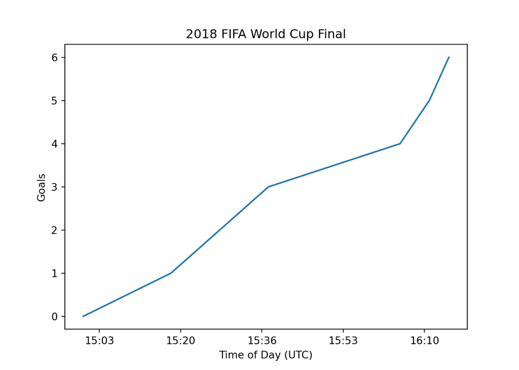

```python
import matplotlib.pyplot as plt
import matplotlib.ticker as ticker
import time

goals = [0, 1, 2, 3, 4, 5, 6]

ax = plt.axes()
ax.plot(seconds_since_epoch, goals)
ax.set_title('2018 FIFA World Cup Final')
ax.set_ylabel('Goals')
ax.set_xlabel('Time of Day (UTC)')
# Convert seconds-since-epoch numbers into struct_time objects and then to
# strings (you can use time.localtime() instead of time.gmtime() to get the
# time in your local timezone)
fmt = ticker.FuncFormatter(lambda x, pos: time.strftime('%H:%M', time.gmtime(x)))
ax.xaxis.set_major_formatter(fmt)

plt.show()
```

This example was done using UTC as opposed to the local time (MSK), which explains why the graph starts at 3pm when kickoff in Moscow (UTC+3) was actually 6pm. Incorporating time zone information when using the `time` module is a little tricky, and you should probably use the `datetime` module if this is what you want to do.

## 1.2 `struct_time` Objects

Similarly, the date and time of the start of the match and the six goals can be represented as `struct_time` objects. Remember, this object type is a 9-tuple of information: the year, month, day, hour, minute, second, day of the week, day of the year and daylight savings information:

```python
time_structs = [
    time.struct_time((2018, 7, 15, 15, 0, 0, 6, 196, -1)),
    time.struct_time((2018, 7, 15, 15, 18, 0, 6, 196, -1)),
    time.struct_time((2018, 7, 15, 15, 28, 0, 6, 196, -1)),
    time.struct_time((2018, 7, 15, 15, 38, 0, 6, 196, -1)),
    time.struct_time((2018, 7, 15, 16, 5, 0, 6, 196, -1)),
    time.struct_time((2018, 7, 15, 16, 11, 0, 6, 196, -1)),
    time.struct_time((2018, 7, 15, 16, 15, 0, 6, 196, -1))
]
```

These cannot be plotted immediately, but first need to be converted into seconds-since-the-epoch numbers:

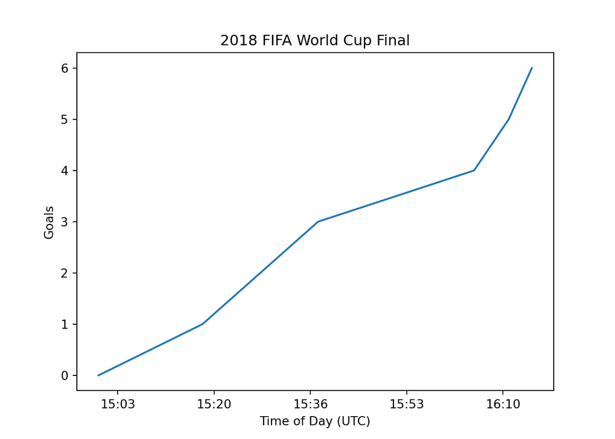

```python
import matplotlib.pyplot as plt
import matplotlib.ticker as ticker
import time
import calendar

goals = [0, 1, 2, 3, 4, 5, 6]

ax = plt.axes()
# Convert struct_time object in UTC to seconds-since-epoch
seconds_since_epoch = [calendar.timegm(ts) for ts in time_structs]
ax.plot(seconds_since_epoch, goals)
ax.set_title('2018 FIFA World Cup Final')
ax.set_ylabel('Goals')
ax.set_xlabel('Time of Day (UTC)')
# Convert seconds-since-epoch numbers into struct_time objects and then to
# strings (you can use time.localtime() instead of time.gmtime() to get the
# time in your local timezone)
fmt = ticker.FuncFormatter(lambda x, pos: time.strftime('%H:%M', time.gmtime(x)))
ax.xaxis.set_major_formatter(fmt)

plt.show()
```

This example was again done using UTC as opposed to the local time (MSK), so the graph still starts at 3pm when kickoff in Moscow (UTC+3) was actually 6pm. If you are wanting to work with ‘aware’ objects (ie objects which include timezone information, as opposed to ‘naive’ objects) you should probably use the `datetime` module.

# 2 Plotting Time Data Using the `datetime` Module

## 2.1 `datetime.time` Objects

These objects contain only the time at which something occurred (not the date):

```python
import datetime

times = [
    datetime.time(18, 0), datetime.time(18, 18), datetime.time(18, 28),
    datetime.time(18, 38), datetime.time(19, 5), datetime.time(19, 11),
    datetime.time(19, 15)
]
```

Unfortunately, these objects cannot immediately be plotted on a graph; they first need to be converted into `datetime.datetime` objects. This can be done by adding arbitrary date information to the time information via the `datetime.datetime.combine()` function:

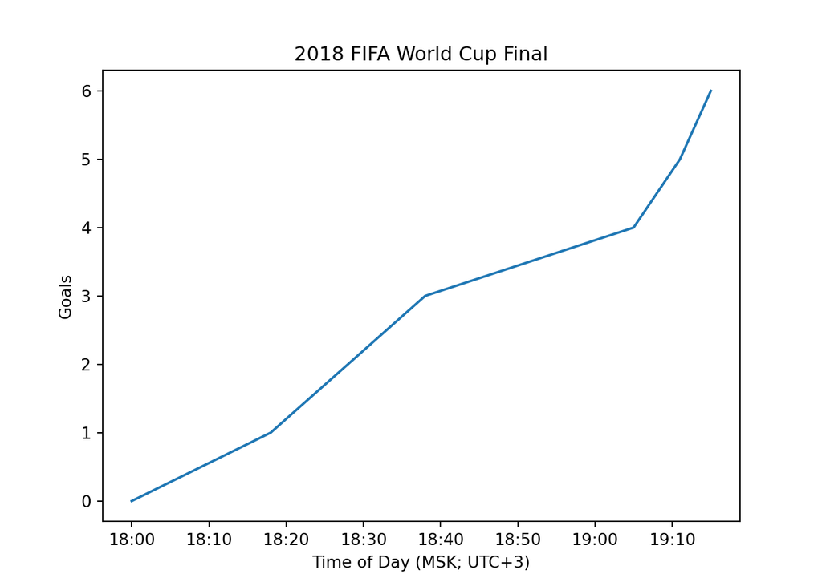

```python
import matplotlib.pyplot as plt
import datetime
import matplotlib.dates as mdates

goals = [0, 1, 2, 3, 4, 5, 6]

ax = plt.axes()
# Convert datetime.time objects into datetime.datetime objects by adding a date
# to the time
datetimes = [datetime.datetime.combine(datetime.date.today(), t) for t in times]
ax.plot(datetimes, goals)
ax.set_title('2018 FIFA World Cup Final')
ax.set_ylabel('Goals')
ax.set_xlabel('Time of Day (MSK; UTC+3)')
# Re-format the x-axis
fmt = mdates.DateFormatter('%H:%M')
ax.xaxis.set_major_formatter(fmt)

plt.show()
```

## 2.2 `datetime.date` Objects

These objects contain only the date on which something occurred (not the time). As an example, let’s use the number of runs scored on each day of [the final match of the 2005 Ashes series](https://www.espncricinfo.com/series/australia-tour-of-england-and-scotland-2005-139019/england-vs-australia-5th-test-218383/full-scorecard):

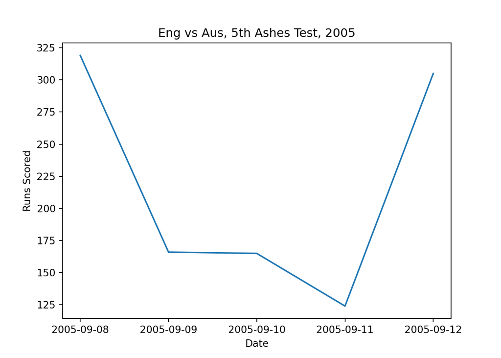

```python
import matplotlib.pyplot as plt
import datetime
import matplotlib.dates as mdates

dates = [
    datetime.date(2005, 9, 8), datetime.date(2005, 9, 9), datetime.date(2005, 9, 10),
    datetime.date(2005, 9, 11), datetime.date(2005, 9, 12)
]
runs = [319, 166, 165, 124, 305]

ax = plt.axes()
# Convert to datetime.datetime object by adding a time to the date
datetimes = [datetime.datetime.combine(d, datetime.datetime.min.time()) for d in dates]
ax.plot(datetimes, runs)
ax.set_title('Eng vs Aus, 5th Ashes Test, 2005')
ax.set_ylabel('Runs Scored')
ax.set_xlabel('Date')
ax.set_xticks(dates)
# Re-format the x-axis
fmt = mdates.DateFormatter('%Y-%m-%d')
ax.xaxis.set_major_formatter(fmt)

plt.show()
```

## 2.3 `datetime.datetime` Objects

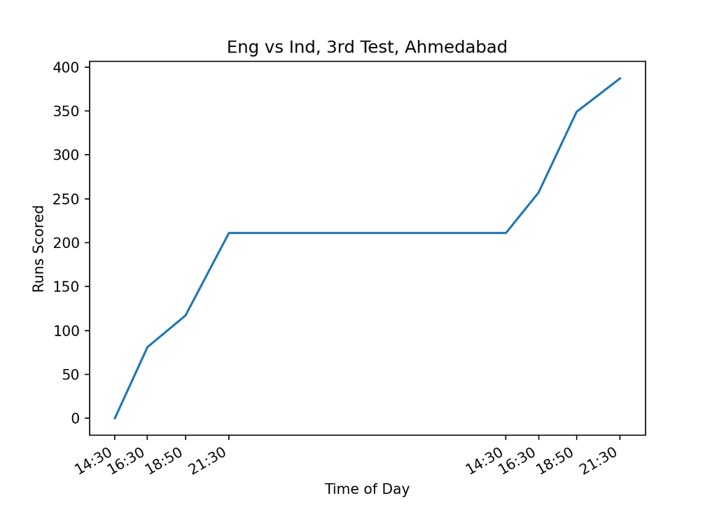

```python
import matplotlib.pyplot as plt
import datetime
import matplotlib.dates as mdates

datetimes = [
    datetime.datetime(2021, 2, 24, 14, 30), datetime.datetime(2021, 2, 24, 16, 30),
    datetime.datetime(2021, 2, 24, 18, 50), datetime.datetime(2021, 2, 24, 21, 30),
    datetime.datetime(2021, 2, 25, 14, 30), datetime.datetime(2021, 2, 25, 16, 30),
    datetime.datetime(2021, 2, 25, 18, 50), datetime.datetime(2021, 2, 25, 21, 30)
]
runs = [0, 81, 117, 211, 211, 257, 349, 387]

ax = plt.axes()
ax.plot(datetimes, runs)
ax.set_title('Eng vs Ind, 3rd Test, Ahmedabad')
ax.set_ylabel('Runs Scored')
ax.set_xlabel('Time of Day')
# Re-format the x-axis
ax.set_xticks(datetimes)
ax.set_xticklabels(datetimes, rotation=30, ha='right')
fmt = mdates.DateFormatter('%H:%M')
ax.xaxis.set_major_formatter(fmt)
plt.subplots_adjust(bottom=0.15)

plt.show()
```

# 3 Double Axes

When working with time data, it’s sometimes useful to display it in two different formats. Here’s an example that does this by creating a second, twinned set of the axes and changing the format of the second one:

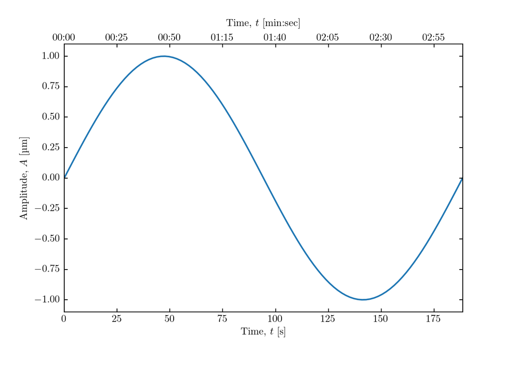

```python
import matplotlib.pyplot as plt
from mpl_toolkits.axes_grid1 import host_subplot
import mpl_toolkits.axisartist as AA
import numpy as np
import math
import matplotlib.ticker as ticker
import time

# Set image size to A5
A = 5
plt.rc('figure', figsize=[46.82 * .5**(.5 * A), 33.11 * .5**(.5 * A)])
# Enable Latex
plt.rc('font', family='serif')
plt.rc('text', usetex=True)

# Fake up some data
x = np.linspace(0, 30 * math.tau, 100)
y = np.sin(x / 30)

#
# Plot
#
ax1 = host_subplot(111, axes_class=AA.Axes)
ax1.plot(x, y)
ax1.set_ylabel(r'Amplitude, $A$ [\textmu m]')
ax1.set_xlabel(r'Time, $t$ [s]')
ax1.set_xlim(0, 30 * math.tau)
# Twin the axes
ax2 = ax1.twin()
# Edit the second set of axes
ax2.set_xlabel(r'Time, $t$ [min:sec]')
fmt = ticker.FuncFormatter(lambda x, pos: time.strftime('%M:%S', time.gmtime(x)))
ax2.xaxis.set_major_formatter(fmt)
ax2.axis['right'].major_ticklabels.set_visible(False)
ax2.axis['top'].major_ticklabels.set_visible(True)
ax2.axis['top'].label.set_visible(True)

plt.show()
```

Notice that this example plots *numbers* on the x-axis, and as such they get interpreted as seconds-since-the-epoch when they are being re-formatted into time. The axis at the top of the image is thus actually showing time in minutes and seconds *after midnight on 1 January 1970*, which isn’t really what the data is representing. It doesn’t matter though, because it doesn’t affect the plot itself.

⇦ Back